# Final Project

Shynitha Pulluri

2026-10-31

# Introduction

The Youth Risk Behavior Surveillance System (YRBSS) monitors health behaviors and experiences among high school students in the United States. The dataset used in this analysis contains prevalence estimates for mental health, suicide-related behaviors, and selected substance-use indicators across U.S. states and various demographic groups for 2019, 2021, and 2023. Variables include survey year, geographic area, demographic group, estimated percent, and corresponding 95% confidence intervals.

The objectives of this analysis are to describe the prevalence of mental health, suicide-related, and substance-use indicators among U.S. high school students in 2023 and to examine changes in sadness or hopelessness prevalence among female and male students from 2019 through 2023.

# Descriptive Analysis

## Tabular analysis

Mental Health and Substance Use Indicators Among U.S. High School Students, 2023

| Mental Health Indicator | Percent |
| --- | --- |
| Persistent sadness or hopelessness | 39.7 |
| Seriously considered suicide | 20.4 |
| Made a suicide plan | 16.4 |
| Attempted suicide | 9.5 |
| Poor mental health | 28.5 |
| Prescription pain medicine misuse | 11.6 |
| Illicit drug use | 9.9 |

### Table One Description

Table 1 presents the prevalence of seven mental health, suicide-related, and substance-use indicators among U.S. high school students in 2023. Persistent sadness or hopelessness had the highest reported prevalence at 39.7%, followed by poor mental health at 28.5% and seriously considering suicide at 20.4%. Suicide attempts and illicit drug use had the lowest reported percentages, at 9.5% and 9.9%, respectively.

## Data Visualization

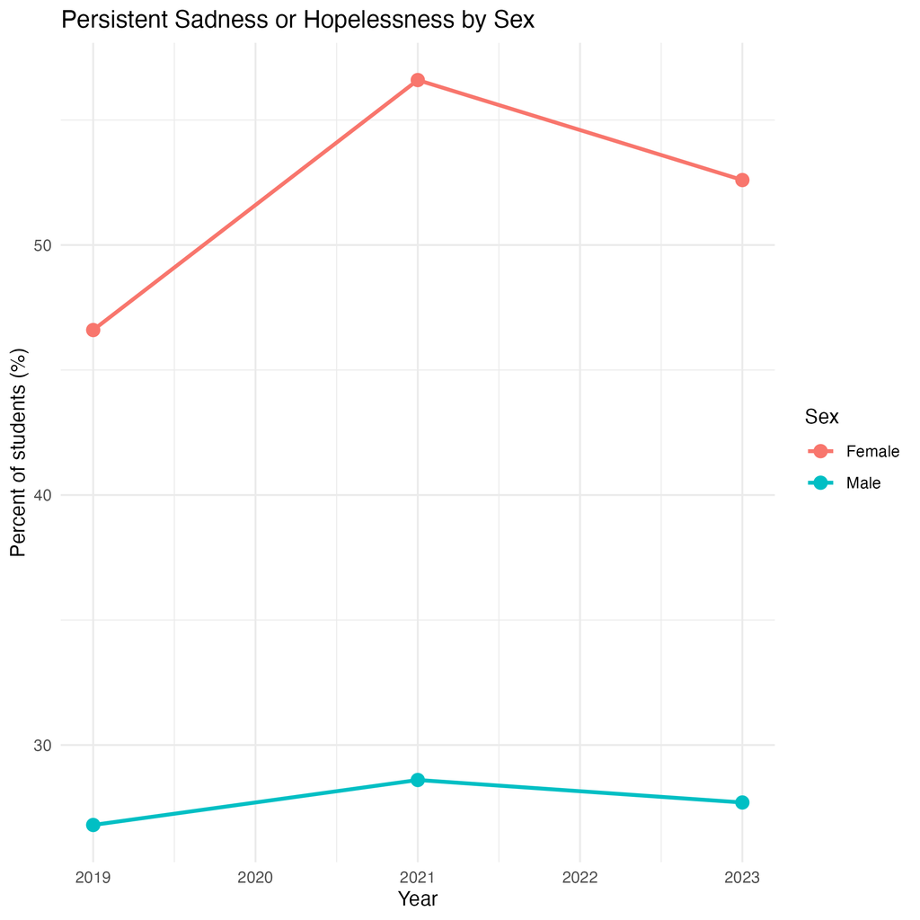

### Figure One Description

Figure 1 shows changes in the percentage of female and male U.S. high school students reporting persistent sadness or hopelessness from 2019 to 2023. Among female students, the percentage increased from 46.6% in 2019 to 56.6% in 2021, and decreased to 52.6% in 2023. Among male students, the percentages were relatively stable, increasing from 26.8% in 2019 to 28.6% in 2021 and then decreasing to 27.7% in 2023. Female students reported a higher percentage of persistent sadness or hopelessness than male students during all three survey years.